# Final CRIB Sedentary-Time Analysis: Adults

Christopher Odoom

2026-09-23

## Purpose

This report reproduces the substantive manuscript analyses using the CRIB minute-level sleep classification and CHAP sitting predictions. It is limited to participants aged 18 years or older with at least one eligible day. Supplementary analyses compare four waking-time methods, vary CRIB parameters on the same primary sample, and assess a minimum-two-day eligibility requirement. Sleep-cutoff calibration is used only for the supplementary SWaN method comparison.

The primary sitting classification is `wake_ind == "wake"`. A measurement day is retained when it contains exactly 1,440 minutes with complete CHAP predictions and CRIB identifies at least one wake minute. No day is excluded based on the duration of released NHANES `Non-wear` sequences during CRIB processing. After CRIB processing, a midnight-to-midnight day is excluded if any original NHANES non-wear run is not bounded on both sides within that day by known Wake or Sleep states. Unknown does not qualify on either side, and the flanking states may be the same. Wake–Non-wear–Wake and Sleep–Non-wear–Sleep therefore qualify. Participants must have at least one retained day. Later passing days remain eligible even if an earlier day was excluded.

## Input-data construction and analytic selections

The CRIB input starts with the NHANES minute-level sleep cache and CHAP 1-minute sitting-prediction parquet files. For each participant and NHANES cycle, the batch workflow obtains the participant list from `wristsed::available_participants()`, reads the matching sleep cache, and reads all CHAP `part-*.parquet` files in the participant’s `Day=YYYY-MM-DD` directories. Sleep and CHAP records are matched using participant ID, NHANES wear day, and minute index. The CHAP sitting fraction is the proportion of the minute classified as sitting.

The released NHANES prediction (`PAXPREDM`) is recoded as `Wake`, `Sleep`, `Non-wear`, or `Unknown`. CRIB is applied to the ordered one-minute sleep-state vector using these fixed settings:

```
method                              CRIB
target                              Sleep
target buffer                       10 minutes
longest allowable interruption      10 minutes
required target percentage          80 percent
maximum interruptions               unlimited
minimum bout duration               30 minutes
epoch length                        60 seconds
```

The expanded CRIB output supplies `wake_ind`. The primary sitting analysis uses only minutes where `wake_ind == "wake"`. The `sleep_prediction_new` interruption label is therefore handled by the CRIB classification and is not used as an additional non-wear filter.

Day eligibility is determined before the participant summaries are created. A day must contain exactly 1,440 minute records with complete CHAP predictions and at least one `wake_ind == "wake"` minute after CRIB processing. No separate non-wear duration screen is applied at the day-processing step.

Daily sedentary minutes are the sum of `chap_sitting_fraction` over CRIB wake minutes; dividing by 60 gives sedentary hours. These time estimates do not threshold the sitting fractions. The 0.50 threshold is used only for the CHAP classification strip in Figure 1B and sedentary-bout identification in Figure 4.

Non-wear eligibility is applied after CRIB, using the original NHANES states. A day passes if it has no non-wear or every non-wear run is bounded within the same midnight-to-midnight day by known Wake or Sleep states, whether those states are the same or different. Unknown on either side does not qualify. Runs that reach a day boundary or lack an observed state on either side cause the whole day to be excluded. Runs are not joined across days for this eligibility rule. There is no additional duration threshold for qualifying within-day transitions.

A participant-cycle must have at least one eligible day, age >=18, and complete examination weight, masked variance stratum, and PSU metadata. Eligible days are averaged within participant-cycle before survey estimation. Requiring at least two eligible days is retained as a sensitivity analysis. These are complete 24-hour records passing the specified non-wear rule, not confirmed 24-hour wear: qualifying transition non-wear can remain.

## Sample inclusion flow

Supplementary Figure S1 shows the complete sample pathway from all NHANES participants with accelerometer data. It distinguishes input processing, adult survey-design eligibility, the complete-day/CHAP-match screen, the requirement for some CRIB waking time, and the within-day non-wear screen. The final sample includes participants with one eligible day.

Across the two cycles, 14,693 participants had accelerometer data. Of these, 85 were excluded before CRIB analysis because they had no complete-day data (n = 79) or a SWaN sleep-prediction processing failure (n = 6).

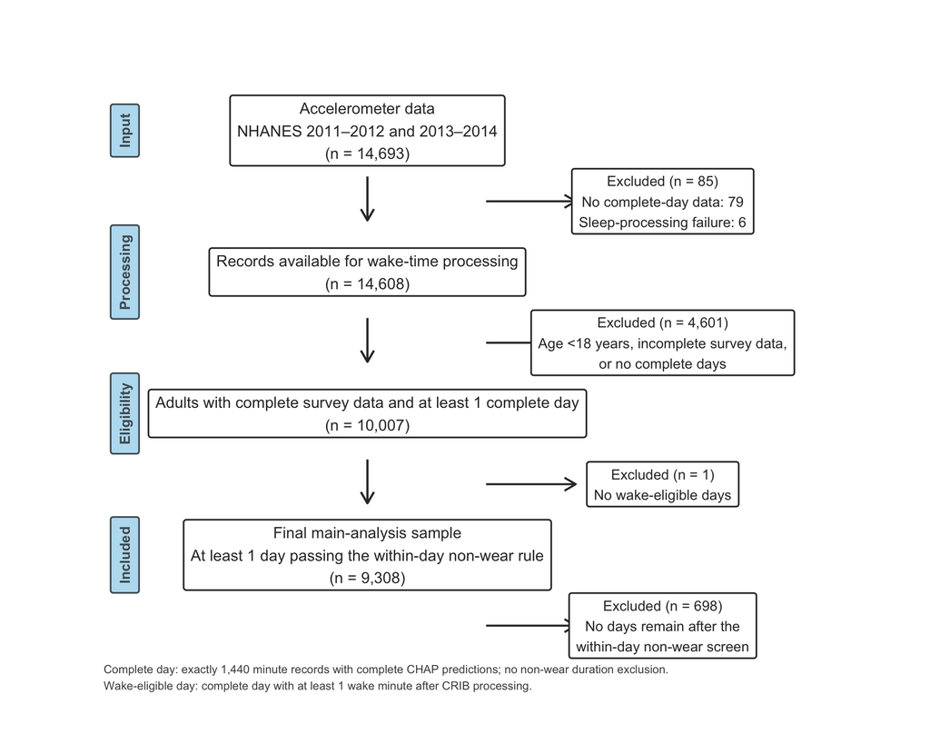

The final sample includes **9,308 adults (93.0% of adults with at least one complete day)** and 55,722 eligible days. One adult had no complete days containing CRIB wake minutes; another 698 adults had no days remaining after the bounded non-wear screen. This screen allows matching as well as differing states on either side of a non-wear run.

Participant-cycles with no eligible day are excluded. Fully asleep hours within retained days remain in the hourly analysis and contribute zero waking and waking sedentary time. The upstream audit identifies seven complete days with zero CRIB wake time; five were entirely labelled Sleep in the original NHANES states. These days are excluded before the non-wear screen.

Post-CRIB within-day non-wear eligibility.

| original_wake_eligible_days | nonwear_excluded_days | primary_eligible_days |
| --- | --- | --- |
| 69010 | 13288 | 55722 |

Retained non-wear run durations (minutes; unweighted).

| runs | participants | days | total_minutes | minimum_minutes | p25_minutes | median_minutes | p75_minutes | p90_minutes | p95_minutes | maximum_minutes |
| --- | --- | --- | --- | --- | --- | --- | --- | --- | --- | --- |
| 398 | 359 | 392 | 135770 | 39 | 114.2 | 298.5 | 487.8 | 676.3 | 793.6 | 1281 |

Distribution of retained non-wear run durations (minutes).

| duration | runs | percent |
| --- | --- | --- |
| 1–5 | 0 | 0.0 |
| 6–10 | 0 | 0.0 |
| 11–20 | 0 | 0.0 |
| 21–30 | 0 | 0.0 |
| 31–60 | 62 | 15.6 |
| 61–120 | 43 | 10.8 |
| 121–240 | 55 | 13.8 |
| 241–480 | 130 | 32.7 |
| >480 | 108 | 27.1 |

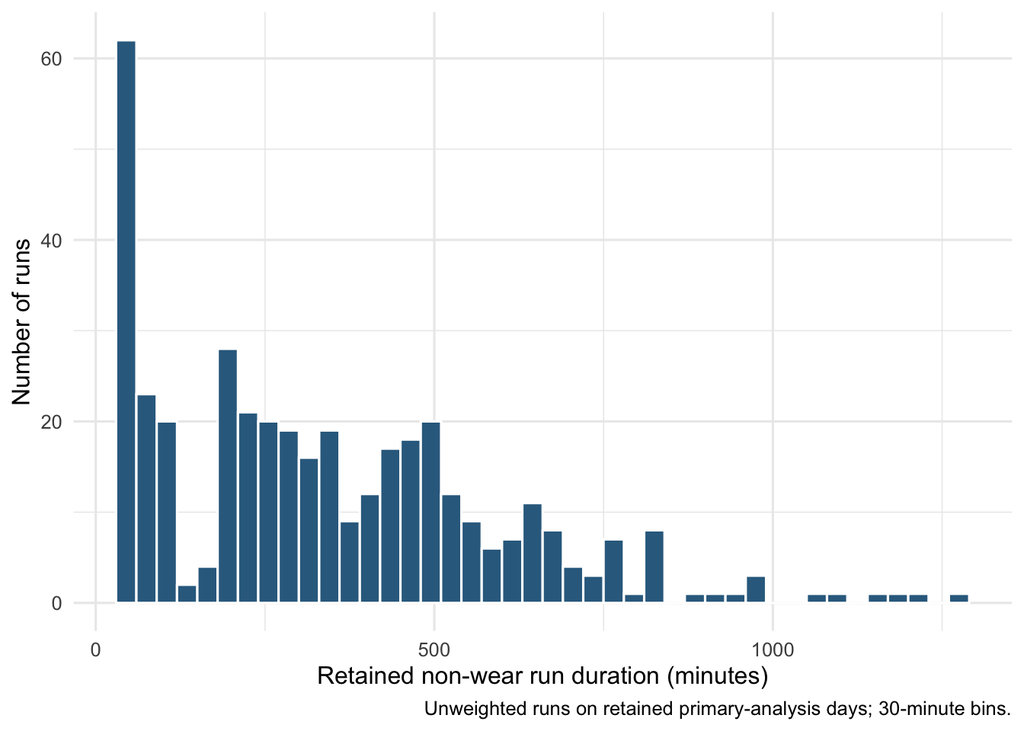

The retained sample contains 398 non-wear runs on 392 days in 359 adults. All have Wake on both sides; no retained runs have Sleep on either side. The median run duration is 298.5 minutes (IQR 114.2–487.8), with a range of 39–1281 minutes. 0 runs are 30 minutes or shorter; 15.6% are 60 minutes or shorter. A run is a maximal uninterrupted sequence of original NHANES Non-wear minutes; its length excludes the Wake/Sleep minutes on either side. For example, Sleep–Non-wear–Non-wear–Sleep contributes one 2-minute run. Separate runs within a day contribute separate observations, rather than their combined daily total. For example, a retained day containing separate 41-minute and 251-minute runs contributes those two durations, not a single 292-minute duration. These summaries describe observed runs and are not survey-weighted population estimates.

Non-wear labels bounded by known Wake or Sleep states could reflect classification error, but they could also represent actual device removal. Their duration distribution does not support characterizing the retained runs as predominantly brief classification artifacts. The boundary rule is an operational eligibility choice; it does not establish that the retained intervals represent true wear. No duration cutoff was used to select these runs.

### Independent check against original NHANES files

This audit reads the original CDC `PAXMIN_G.xpt` and `PAXMIN_H.xpt` files directly, before CRIB processing, CHAP matching, or day exclusions. All four state-frequency totals in each file agree exactly with the CDC codebooks. The run distribution uses consecutive `PAXPREDM == 3` minute records, preserving runs across midnight when the recording is continuous. Record-edge runs describe observed lengths and may be truncated. These are unweighted run-level summaries.

Non-wear run durations from original NHANES files versus retained report runs.

| Sample | Runs | Minimum (min) | Median (min) | 25th percentile (min) | 75th percentile (min) | 1-minute runs | 2-minute runs | Runs ≤30 minutes (%) |
| --- | --- | --- | --- | --- | --- | --- | --- | --- |
| All NHANES participants; continuous runs | 58498 | 1 | 138.0 | 26.0 | 452.0 | 2373 | 1627 | 26.9 |
| All adults; continuous runs | 39362 | 1 | 137.0 | 26.0 | 437.0 | 1572 | 1106 | 26.6 |
| Final report retained runs | 398 | 39 | 298.5 | 114.2 | 487.8 | 0 | 0 | 0.0 |

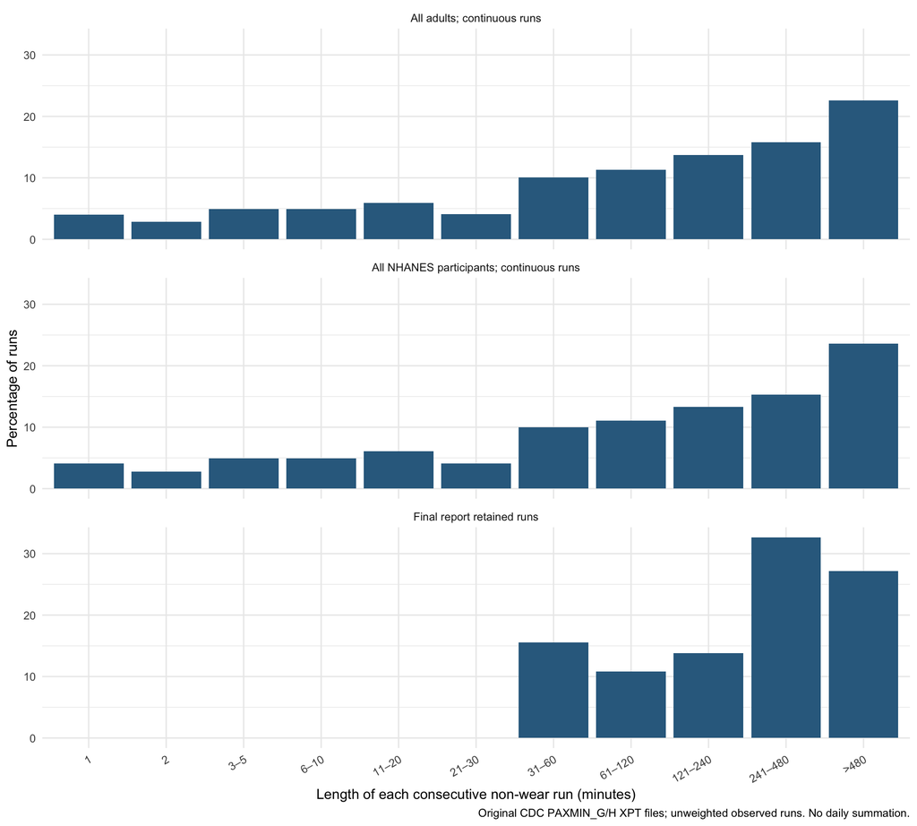

Before day screening, 1,882 adult runs have known Wake/Sleep states immediately on both sides; their minimum duration is already 39 minutes. Thus this minimum is present before day eligibility selection. The shorter adult runs have Unknown or a recording edge/gap on at least one side.

Short non-wear runs occur in the original NHANES files. Their presence in the unfiltered files must be distinguished from their eligibility under the report’s known-boundary day screen. The original-file audit independently reproduces the individual lengths and immediate flanking states of every retained non-wear run. Eligibility is attached after the original runs are identified; each retained run must have exactly the same duration before and after screening. See the [2011–2012 CDC codebook](https://wwwn.cdc.gov/Nchs/Data/Nhanes/Public/2011/DataFiles/PAXMIN_G.htm) and [2013–2014 CDC codebook](https://wwwn.cdc.gov/Nchs/Data/Nhanes/Public/2013/DataFiles/PAXMIN_H.htm).

Sensitivity analysis requiring at least two days passing the same non-wear rule.

| Measure | N | Mean (95% CI), h/day |
| --- | --- | --- |
| Waking sedentary time | 8989 | 9.81 (9.74, 9.88) |
| CRIB-excluded time | 8989 | 7.99 (7.93, 8.06) |
| Waking time | 8989 | 16.01 (15.94, 16.07) |

## Pooled and cycle-specific time estimates

Survey-weighted adult estimates of waking, CRIB-excluded, waking sedentary, and waking non-sedentary time, pooled and by NHANES cycle. Values are mean (SE; 95% CI) hours/day.

| Measure | Pooled (2011-2014) | 2011-2012 | 2013-2014 |
| --- | --- | --- | --- |
| Waking time | 15.97 (0.04; 15.89, 16.05) | 15.98 (0.07; 15.85, 16.11) | 15.96 (0.04; 15.88, 16.05) |
| CRIB-excluded time | 8.03 (0.04; 7.95, 8.11) | 8.02 (0.07; 7.89, 8.15) | 8.04 (0.04; 7.95, 8.12) |
| Waking sedentary time | 9.79 (0.03; 9.73, 9.86) | 9.77 (0.05; 9.66, 9.87) | 9.82 (0.04; 9.75, 9.89) |
| Waking non-sedentary time | 6.18 (0.04; 6.10, 6.26) | 6.21 (0.06; 6.09, 6.34) | 6.14 (0.05; 6.05, 6.24) |

### Difference between NHANES cycles

Survey-weighted difference in adult CRIB sedentary time between NHANES cycles.

| contrast | difference_hours | SE | p_value |
| --- | --- | --- | --- |
| 2013-2014 minus 2011-2012 | 0.05 | 0.07 | 0.44 |

## Comparison of waking-time methods

All four methods use the adopted primary eligibility: complete days with some CRIB waking time that pass the original NHANES within-day non-wear screen, with at least one eligible common day per participant. The shared day set is then restricted to days with complete inputs for all methods. The SWaN cutoff is calibrated within this common sample.

The following comparison places NHANES + CRIB on those common days alongside three alternative approaches: direct one-hour SWaN states, a one-hour SWaN cutoff calibrated to self-reported sleep in the common analytic domain, and direct one-hour NHANES sleep states. To isolate differences attributable to the sleep/wake approach, every method is estimated on the same adult participant-cycles and their mutually available eligible days.

For every approach, excluded time is the complement of waking time, so the two sum to 24 hours/day. Its operational definition differs by method: for direct SWaN states, it includes SWaN sleep/non-wear and any residual unclassified time; for the calibrated SWaN cutoff, it is time in hours at or above the sleep/non-wear percentage cutoff; for direct NHANES states, it includes released sleep, non-wear, and Unknown time; and for NHANES + CRIB, it is the final binary CRIB `sleep` label (the relabelled Sleep plus interruption class). Waking sedentary and non-sedentary time partition waking time.

Survey-weighted waking-time estimates across four sleep/wake approaches, evaluated in the common adult participant-cycle sample (N = 9,308). The SWaN cutoff was calibrated within this domain among participants with valid self-reported sleep duration (n = 9,295). Excluded time is method-specific but, for every method, is the complement of waking time; the two sum to 24 hours/day. Values are mean (95% CI) hours/day.

| Measure | Direct SWaN states | SWaN + calibrated cutoff | Direct NHANES states | NHANES + CRIB |
| --- | --- | --- | --- | --- |
| Waking time | 13.01 (12.90, 13.11) | 17.10 (17.04, 17.15) | 14.90 (14.80, 14.99) | 15.97 (15.89, 16.05) |
| Excluded time | 10.99 (10.89, 11.10) | 6.90 (6.85, 6.96) | 9.10 (9.01, 9.20) | 8.03 (7.95, 8.11) |
| Waking sedentary time | 7.01 (6.94, 7.09) | 10.92 (10.85, 10.98) | 8.75 (8.67, 8.82) | 9.79 (9.73, 9.86) |
| Waking non-sedentary time | 5.99 (5.91, 6.07) | 6.18 (6.10, 6.26) | 6.15 (6.07, 6.23) | 6.18 (6.10, 6.26) |

The comparison includes 9,308 participants and 55,722 common primary-eligible days, out of 9,308 primary participants and 55,722 primary days. It includes 319 participants with one common day.

All primary participants and days have complete inputs for the four methods, so the CRIB comparison estimate uses the full primary sample.

Within the common analytic domain, the survey-weighted self-reported sleep benchmark was 6.94 hours/day (95% CI: 6.90–6.98). The selected one-hour SWaN cutoff was 83.34%, which yielded 6.91 hours/day in the calibration sample.

## Supplementary CRIB parameter sensitivity

We varied required sleep (70%, 80%, and 90%) and minimum bout duration (20, 30, 45, and 60 minutes), holding the other CRIB parameters fixed. All 12 specifications use the same 9,308 adults and 55,722 days selected by the primary within-day non-wear rule. CRIB is applied to each participant’s full sequence of complete CHAP-matched days before selecting the primary analytic days. Eligibility is not re-evaluated under alternative settings; a primary-eligible day classified entirely as sleep under an alternative setting contributes zero waking sedentary time.

For each participant, daily waking sedentary hours are averaged over those same days. Each table cell reports the survey-weighted mean paired difference from the primary 80%/30-minute setting and its two-sided p-value, overall or within the indicated subgroup. Positive differences indicate more estimated waking sedentary time. The tests assess whether the mean paired difference is zero; they do not test whether effects differ between subgroups. P-values are unadjusted for multiple comparisons.

CRIB parameter sensitivity: difference from the primary estimate

| Group | N | 70% required sleep 20 min | 70% required sleep 30 min | 70% required sleep 45 min | 70% required sleep 60 min | 80% required sleep 20 min | 80% required sleep 30 min | 80% required sleep 45 min | 80% required sleep 60 min | 90% required sleep 20 min | 90% required sleep 30 min | 90% required sleep 45 min | 90% required sleep 60 min |
| --- | --- | --- | --- | --- | --- | --- | --- | --- | --- | --- | --- | --- | --- |
| All adults | 9,308 | -0.28 (<0.001) | -0.06 (<0.001) | +0.22 (<0.001) | +0.47 (<0.001) | -0.22 (<0.001) | 0.00 (Ref.) | +0.27 (<0.001) | +0.51 (<0.001) | +0.15 (<0.001) | +0.45 (<0.001) | +0.79 (<0.001) | +1.09 (<0.001) |
| Sex |  |  |  |  |  |  |  |  |  |  |  |  |  |
| Male | 4,465 | -0.30 (<0.001) | -0.07 (<0.001) | +0.23 (<0.001) | +0.51 (<0.001) | -0.23 (<0.001) | 0.00 (Ref.) | +0.29 (<0.001) | +0.55 (<0.001) | +0.19 (<0.001) | +0.51 (<0.001) | +0.87 (<0.001) | +1.20 (<0.001) |
| Female | 4,843 | -0.25 (<0.001) | -0.05 (<0.001) | +0.21 (<0.001) | +0.44 (<0.001) | -0.20 (<0.001) | 0.00 (Ref.) | +0.25 (<0.001) | +0.47 (<0.001) | +0.12 (<0.001) | +0.40 (<0.001) | +0.72 (<0.001) | +1.00 (<0.001) |
| Age |  |  |  |  |  |  |  |  |  |  |  |  |  |
| 18-34 | 2,643 | -0.23 (<0.001) | -0.05 (<0.001) | +0.18 (<0.001) | +0.39 (<0.001) | -0.18 (<0.001) | 0.00 (Ref.) | +0.22 (<0.001) | +0.42 (<0.001) | +0.19 (<0.001) | +0.46 (<0.001) | +0.78 (<0.001) | +1.06 (<0.001) |
| 35-44 | 1,475 | -0.23 (<0.001) | -0.05 (<0.001) | +0.18 (<0.001) | +0.39 (<0.001) | -0.18 (<0.001) | 0.00 (Ref.) | +0.22 (<0.001) | +0.41 (<0.001) | +0.15 (<0.001) | +0.41 (<0.001) | +0.71 (<0.001) | +0.98 (<0.001) |
| 45-64 | 3,102 | -0.28 (<0.001) | -0.06 (<0.001) | +0.22 (<0.001) | +0.47 (<0.001) | -0.22 (<0.001) | 0.00 (Ref.) | +0.27 (<0.001) | +0.51 (<0.001) | +0.14 (<0.001) | +0.43 (<0.001) | +0.77 (<0.001) | +1.06 (<0.001) |
| >=65 | 2,088 | -0.38 (<0.001) | -0.08 (<0.001) | +0.32 (<0.001) | +0.67 (<0.001) | -0.30 (<0.001) | 0.00 (Ref.) | +0.38 (<0.001) | +0.71 (<0.001) | +0.14 (<0.001) | +0.51 (<0.001) | +0.94 (<0.001) | +1.31 (<0.001) |
| BMI |  |  |  |  |  |  |  |  |  |  |  |  |  |
| Underweight | 187 | -0.21 (<0.001) | -0.04 (<0.001) | +0.23 (<0.001) | +0.53 (<0.001) | -0.18 (<0.001) | 0.00 (Ref.) | +0.26 (<0.001) | +0.54 (<0.001) | +0.19 (<0.001) | +0.47 (<0.001) | +0.83 (<0.001) | +1.16 (<0.001) |
| Normal weight | 2,713 | -0.25 (<0.001) | -0.05 (<0.001) | +0.21 (<0.001) | +0.44 (<0.001) | -0.20 (<0.001) | 0.00 (Ref.) | +0.25 (<0.001) | +0.47 (<0.001) | +0.14 (<0.001) | +0.41 (<0.001) | +0.73 (<0.001) | +1.00 (<0.001) |
| Overweight | 2,899 | -0.27 (<0.001) | -0.06 (<0.001) | +0.22 (<0.001) | +0.45 (<0.001) | -0.21 (<0.001) | 0.00 (Ref.) | +0.26 (<0.001) | +0.48 (<0.001) | +0.15 (<0.001) | +0.44 (<0.001) | +0.77 (<0.001) | +1.06 (<0.001) |
| Obesity | 3,407 | -0.30 (<0.001) | -0.07 (<0.001) | +0.24 (<0.001) | +0.51 (<0.001) | -0.24 (<0.001) | 0.00 (Ref.) | +0.29 (<0.001) | +0.55 (<0.001) | +0.17 (<0.001) | +0.49 (<0.001) | +0.86 (<0.001) | +1.18 (<0.001) |
| Race/ethnicity |  |  |  |  |  |  |  |  |  |  |  |  |  |
| Mexican American | 1,135 | -0.23 (<0.001) | -0.05 (<0.001) | +0.20 (<0.001) | +0.43 (<0.001) | -0.19 (<0.001) | 0.00 (Ref.) | +0.24 (<0.001) | +0.46 (<0.001) | +0.18 (<0.001) | +0.47 (<0.001) | +0.82 (<0.001) | +1.12 (<0.001) |
| Other Hispanic | 892 | -0.25 (<0.001) | -0.06 (<0.001) | +0.18 (<0.001) | +0.40 (<0.001) | -0.19 (<0.001) | 0.00 (Ref.) | +0.23 (<0.001) | +0.45 (<0.001) | +0.16 (<0.001) | +0.43 (<0.001) | +0.76 (<0.001) | +1.04 (<0.001) |
| NH White | 3,720 | -0.28 (<0.001) | -0.06 (<0.001) | +0.23 (<0.001) | +0.48 (<0.001) | -0.22 (<0.001) | 0.00 (Ref.) | +0.27 (<0.001) | +0.51 (<0.001) | +0.13 (<0.001) | +0.43 (<0.001) | +0.76 (<0.001) | +1.04 (<0.001) |
| NH Black | 2,217 | -0.29 (<0.001) | -0.07 (<0.001) | +0.22 (<0.001) | +0.51 (<0.001) | -0.22 (<0.001) | 0.00 (Ref.) | +0.28 (<0.001) | +0.55 (<0.001) | +0.23 (<0.001) | +0.57 (<0.001) | +0.97 (<0.001) | +1.33 (<0.001) |
| NH Asian | 1,072 | -0.29 (<0.001) | -0.07 (<0.001) | +0.22 (<0.001) | +0.49 (<0.001) | -0.23 (<0.001) | 0.00 (Ref.) | +0.27 (<0.001) | +0.53 (<0.001) | +0.21 (<0.001) | +0.54 (<0.001) | +0.92 (<0.001) | +1.26 (<0.001) |
| Other/Multi | 272 | -0.27 (<0.001) | -0.07 (<0.001) | +0.20 (<0.001) | +0.47 (<0.001) | -0.21 (<0.001) | 0.00 (Ref.) | +0.25 (<0.001) | +0.52 (<0.001) | +0.14 (<0.001) | +0.44 (<0.001) | +0.79 (<0.001) | +1.09 (<0.001) |

Cells show the survey-weighted paired difference in waking sedentary hours/day (two-sided p-value), alternative setting minus the primary 80%/30-minute setting. Positive values indicate more estimated sedentary time. All 12 settings use the same 9,308 adults and 55,722 primary-eligible days; days are averaged within participant before survey estimation. N is the unweighted subgroup count. P-values use the survey-design t distribution for the mean within-participant difference and are unadjusted for multiple comparisons. Ref. denotes the identical reference setting, for which no test is performed. BMI is missing for 102 participants. Eligibility is fixed to the primary analysis: alternative settings do not select a new cohort.

## Table 2: study comparison

Comparison of sedentary-time estimates across studies by measurement method, datasets, and population.

[output not shown]

## Figure 1: CRIB classification workflow

**Figure 1. Workflow for deriving hourly waking sedentary time from NHANES minute-level classifications and CRIB sleep-bout analysis.** (A) Raw 80-Hz triaxial wrist acceleration summarized in one-minute intervals. (B) One-minute CHAP sedentary predictions, released NHANES wake/sleep/non-wear/unknown classifications, and the corresponding NHANES + CRIB sleep-bout classification. (C) Hourly sleep and CHAP sedentary time retained among CRIB-classified wake minutes; the shaded area follows the sleep curve.

The workflow uses participant 83724 on 2000-01-12 (NHANES wear day 8), a complete 1,440-minute protocol day. Panel A uses the original 80-Hz signal; Panels B and C use the corresponding CRIB batch records. In particular, `chap_sitting_fraction` is the validated one-minute aggregation of the current CHAP 10-second source used by the CRIB sedentary-time analysis.

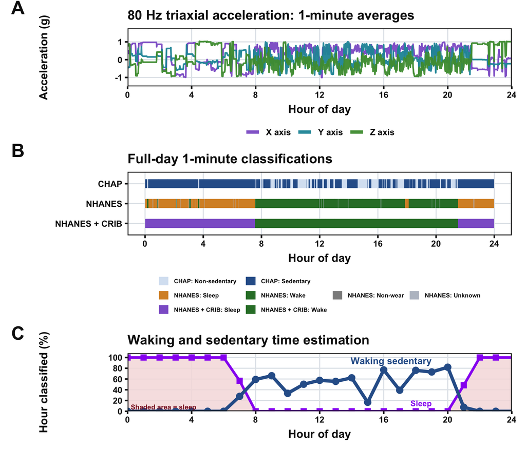

## Table 1: valid-day distribution

Adult CRIB analytic sample and valid measurement-day distribution by NHANES cycle.

| Valid days | 2011-2012 | 2013-2014 | Total (2011-14) |
| --- | --- | --- | --- |
| 1 | 148 (3.2) | 171 (3.6) | 319 (3.4) |
| 2 | 168 (3.6) | 157 (3.3) | 325 (3.5) |
| 3 | 177 (3.8) | 178 (3.8) | 355 (3.8) |
| 4 | 257 (5.6) | 237 (5.1) | 494 (5.3) |
| 5 | 386 (8.4) | 384 (8.2) | 770 (8.3) |
| 6 | 754 (16.3) | 699 (14.9) | 1453 (15.6) |
| 7 | 2726 (59.1) | 2866 (61.1) | 5592 (60.1) |
| Sample analyzed (1+) | 4616 (100.0) | 4692 (100.0) | 9308 (100.0) |

## Hourly waking sedentary profile

The hourly analysis includes all 60 minute samples in each hour of an eligible day. Panel A is the sum of sitting fractions during CRIB wake divided by all minutes in the hour, multiplied by 100. Panel B shows average wake minutes within each hour. Fully asleep hours contribute zero to both panels rather than being omitted. Both panels average days within participant and weekday/weekend category before applying the NHANES survey weights. Participants need at least one eligible day of the relevant day type; this requirement is independent of wake time at any hour. Each labeled hour denotes the hour beginning at that time (00:00 means 00:00–00:59).

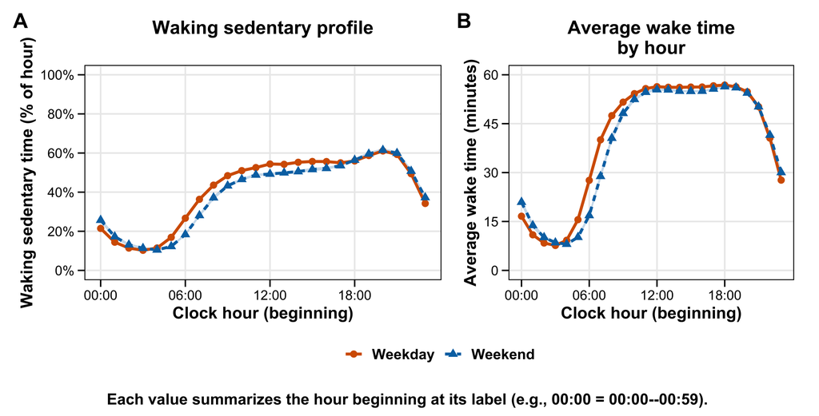

## Figure 3: sedentary-time distribution and 24-hour composition

[figure not shown]

## Figure 4: waking sedentary-bout duration

A waking sedentary bout was defined as consecutive one-minute records classified as CRIB wake with `chap_sitting_fraction >= 0.50`; bouts were not continued across calendar-day boundaries. For each participant-cycle, the mean bout duration was calculated within each retained day and then averaged across days. Thus, the figure describes the distribution of participant-average bout duration rather than the distribution of raw individual bouts.

[figure not shown]

**Figure 4. Average waking sedentary-bout duration in the final adult NHANES + CRIB sample.** (A) Distribution of participant-average waking sedentary-bout duration, grouped into 10-minute intervals; bars are labelled with the number and percentage of participants. (B) Distribution of participant-average bout duration by mean waking sedentary-time group. The annotation identifies the groups with the shortest and longest mean bout duration; boxes show the interquartile range and whiskers show the non-outlying range.

## Figure 5: CRIB parameter sensitivity

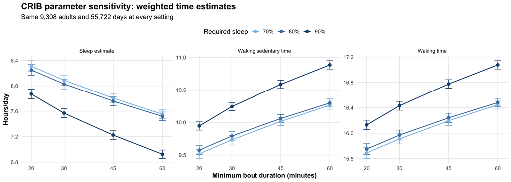

**Figure 5. Survey-weighted estimated sleep, waking sedentary time, and waking time across CRIB parameter settings in the adult analytic sample (N = 9,308).** Lines show estimates for required sleep thresholds of 70%, 80%, and 90% across minimum bout durations of 20, 30, 45, and 60 minutes; error bars indicate pointwise 95% confidence intervals. All settings use the same participants and eligible days. The sleep estimate is time excluded from waking by CRIB, including interruptions within sleep bouts.

## Adult subgroup estimates

Primary age-specific waking sedentary and CRIB-excluded time, hours/day (95% CI).

| Age | N | Sedentary | CRIB-excluded time |
| --- | --- | --- | --- |
| >=65 | 2088 | 10.10 (9.97–10.22) | 8.67 (8.56–8.77) |
| 18-34 | 2643 | 9.79 (9.66–9.91) | 8.02 (7.90–8.14) |
| 35-44 | 1475 | 9.58 (9.42–9.75) | 7.67 (7.60–7.75) |
| 45-64 | 3102 | 9.73 (9.61–9.86) | 7.87 (7.74–8.00) |

### Table 3

Adult CRIB sedentary time by age group and gender, pooled and by NHANES cycle. P values are design-based omnibus Wald tests of equality across levels within each subgroup.

| Subgroup | Category | P value | Pooled (2011-2014): n (%) and mean (95% CI) | 2011-2012: n (%) and mean (95% CI) | 2013-2014: n (%) and mean (95% CI) |
| --- | --- | --- | --- | --- | --- |
| Age group | >=65 | <0.001 | 2088 (22.4%), 10.10 (9.97, 10.22) | 1012 (21.9%), 10.09 (9.88, 10.30) | 1076 (22.9%), 10.10 (9.95, 10.25) |
| Age group | 18-34 |  | 2643 (28.4%), 9.79 (9.66, 9.91) | 1333 (28.9%), 9.81 (9.62, 10.00) | 1310 (27.9%), 9.76 (9.61, 9.91) |
| Age group | 35-44 |  | 1475 (15.8%), 9.58 (9.42, 9.75) | 717 (15.5%), 9.52 (9.30, 9.75) | 758 (16.2%), 9.65 (9.42, 9.87) |
| Age group | 45-64 |  | 3102 (33.3%), 9.73 (9.61, 9.86) | 1554 (33.7%), 9.69 (9.49, 9.88) | 1548 (33.0%), 9.79 (9.64, 9.94) |
| Gender | Male | 0.285 | 4465 (48.0%), 9.83 (9.74, 9.92) | 2273 (49.2%), 9.80 (9.68, 9.93) | 2192 (46.7%), 9.86 (9.73, 9.98) |
| Gender | Female |  | 4843 (52.0%), 9.76 (9.66, 9.85) | 2343 (50.8%), 9.73 (9.56, 9.90) | 2500 (53.3%), 9.78 (9.69, 9.87) |

### Table 4

Adult CRIB sedentary time by race/ethnicity and BMI category, pooled and by NHANES cycle. P values are design-based omnibus Wald tests of equality across levels within each subgroup.

| Subgroup | Category | P value | Pooled (2011-2014): n (%) and mean (95% CI) | 2011-2012: n (%) and mean (95% CI) | 2013-2014: n (%) and mean (95% CI) |
| --- | --- | --- | --- | --- | --- |
| Race/ethnicity | Mexican American | <0.001 | 1135 (12.2%), 8.98 (8.81, 9.15) | 471 (10.2%), 8.89 (8.65, 9.13) | 664 (14.2%), 9.05 (8.83, 9.27) |
| Race/ethnicity | NH Asian |  | 1072 (11.5%), 9.85 (9.66, 10.04) | 591 (12.8%), 9.88 (9.59, 10.16) | 481 (10.3%), 9.82 (9.57, 10.06) |
| Race/ethnicity | NH Black |  | 2217 (23.8%), 10.28 (10.13, 10.42) | 1254 (27.2%), 10.32 (10.11, 10.52) | 963 (20.5%), 10.24 (10.03, 10.44) |
| Race/ethnicity | NH White |  | 3720 (40.0%), 9.84 (9.75, 9.93) | 1696 (36.7%), 9.81 (9.68, 9.95) | 2024 (43.1%), 9.87 (9.76, 9.98) |
| Race/ethnicity | Other Hispanic |  | 892 (9.6%), 9.21 (9.04, 9.38) | 478 (10.4%), 9.08 (8.81, 9.35) | 414 (8.8%), 9.37 (9.16, 9.59) |
| Race/ethnicity | Other/Multi |  | 272 (2.9%), 10.28 (9.92, 10.65) | 126 (2.7%), 10.36 (9.72, 11.00) | 146 (3.1%), 10.22 (9.83, 10.61) |
| BMI category | underweight | <0.001 | 187 (2.0%), 9.75 (9.24, 10.26) | 99 (2.1%), 9.68 (8.97, 10.39) | 88 (1.9%), 9.84 (9.12, 10.56) |
| BMI category | normal weight |  | 2713 (29.1%), 9.46 (9.36, 9.56) | 1371 (29.7%), 9.53 (9.39, 9.66) | 1342 (28.6%), 9.39 (9.25, 9.52) |
| BMI category | overweight |  | 2899 (31.1%), 9.54 (9.42, 9.65) | 1442 (31.2%), 9.44 (9.32, 9.56) | 1457 (31.1%), 9.64 (9.44, 9.84) |
| BMI category | obesity |  | 3407 (36.6%), 10.24 (10.14, 10.33) | 1644 (35.6%), 10.23 (10.06, 10.41) | 1763 (37.6%), 10.24 (10.14, 10.34) |

### Supplementary Table S1

Adult CRIB sedentary time by demographic subgroup, pooled and by NHANES cycle. P values are design-based omnibus Wald tests of equality across levels within each subgroup.

| Subgroup | Category | P value | Pooled (2011-2014): n (%) and mean (95% CI) | 2011-2012: n (%) and mean (95% CI) | 2013-2014: n (%) and mean (95% CI) |
| --- | --- | --- | --- | --- | --- |
| Age group | >=65 | <0.001 | 2088 (22.4%), 10.10 (9.97, 10.22) | 1012 (21.9%), 10.09 (9.88, 10.30) | 1076 (22.9%), 10.10 (9.95, 10.25) |
| Age group | 18-34 |  | 2643 (28.4%), 9.79 (9.66, 9.91) | 1333 (28.9%), 9.81 (9.62, 10.00) | 1310 (27.9%), 9.76 (9.61, 9.91) |
| Age group | 35-44 |  | 1475 (15.8%), 9.58 (9.42, 9.75) | 717 (15.5%), 9.52 (9.30, 9.75) | 758 (16.2%), 9.65 (9.42, 9.87) |
| Age group | 45-64 |  | 3102 (33.3%), 9.73 (9.61, 9.86) | 1554 (33.7%), 9.69 (9.49, 9.88) | 1548 (33.0%), 9.79 (9.64, 9.94) |
| Gender | Male | 0.285 | 4465 (48.0%), 9.83 (9.74, 9.92) | 2273 (49.2%), 9.80 (9.68, 9.93) | 2192 (46.7%), 9.86 (9.73, 9.98) |
| Gender | Female |  | 4843 (52.0%), 9.76 (9.66, 9.85) | 2343 (50.8%), 9.73 (9.56, 9.90) | 2500 (53.3%), 9.78 (9.69, 9.87) |
| Race/ethnicity | Mexican American | <0.001 | 1135 (12.2%), 8.98 (8.81, 9.15) | 471 (10.2%), 8.89 (8.65, 9.13) | 664 (14.2%), 9.05 (8.83, 9.27) |
| Race/ethnicity | NH Asian |  | 1072 (11.5%), 9.85 (9.66, 10.04) | 591 (12.8%), 9.88 (9.59, 10.16) | 481 (10.3%), 9.82 (9.57, 10.06) |
| Race/ethnicity | NH Black |  | 2217 (23.8%), 10.28 (10.13, 10.42) | 1254 (27.2%), 10.32 (10.11, 10.52) | 963 (20.5%), 10.24 (10.03, 10.44) |
| Race/ethnicity | NH White |  | 3720 (40.0%), 9.84 (9.75, 9.93) | 1696 (36.7%), 9.81 (9.68, 9.95) | 2024 (43.1%), 9.87 (9.76, 9.98) |
| Race/ethnicity | Other Hispanic |  | 892 (9.6%), 9.21 (9.04, 9.38) | 478 (10.4%), 9.08 (8.81, 9.35) | 414 (8.8%), 9.37 (9.16, 9.59) |
| Race/ethnicity | Other/Multi |  | 272 (2.9%), 10.28 (9.92, 10.65) | 126 (2.7%), 10.36 (9.72, 11.00) | 146 (3.1%), 10.22 (9.83, 10.61) |
| BMI category | underweight | <0.001 | 187 (2.0%), 9.75 (9.24, 10.26) | 99 (2.1%), 9.68 (8.97, 10.39) | 88 (1.9%), 9.84 (9.12, 10.56) |
| BMI category | normal weight |  | 2713 (29.1%), 9.46 (9.36, 9.56) | 1371 (29.7%), 9.53 (9.39, 9.66) | 1342 (28.6%), 9.39 (9.25, 9.52) |
| BMI category | overweight |  | 2899 (31.1%), 9.54 (9.42, 9.65) | 1442 (31.2%), 9.44 (9.32, 9.56) | 1457 (31.1%), 9.64 (9.44, 9.84) |
| BMI category | obesity |  | 3407 (36.6%), 10.24 (10.14, 10.33) | 1644 (35.6%), 10.23 (10.06, 10.41) | 1763 (37.6%), 10.24 (10.14, 10.34) |
| Education | <9th | <0.001 | 768 (8.3%), 8.89 (8.68, 9.11) | 421 (9.1%), 8.95 (8.64, 9.25) | 347 (7.4%), 8.83 (8.51, 9.14) |
| Education | 9-11th/12ND |  | 1379 (14.8%), 9.46 (9.30, 9.62) | 684 (14.8%), 9.48 (9.29, 9.67) | 695 (14.8%), 9.43 (9.18, 9.69) |
| Education | College+ |  | 2221 (23.9%), 10.16 (10.02, 10.29) | 1113 (24.1%), 10.12 (9.93, 10.31) | 1108 (23.6%), 10.19 (10.01, 10.37) |
| Education | HS grad/GED |  | 2112 (22.7%), 9.46 (9.29, 9.62) | 1000 (21.7%), 9.37 (9.07, 9.66) | 1112 (23.7%), 9.54 (9.38, 9.69) |
| Education | Refused/DK |  | 8 (0.1%), 11.18 (8.73, 13.62) | 3 (0.1%), 11.30 (6.21, 16.39) | 5 (0.1%), 11.14 (8.36, 13.93) |
| Education | Some college/AA |  | 2820 (30.3%), 9.94 (9.83, 10.05) | 1395 (30.2%), 9.93 (9.76, 10.11) | 1425 (30.4%), 9.95 (9.82, 10.08) |
| Marital status | Divorced | <0.001 | 996 (10.7%), 10.05 (9.86, 10.23) | 469 (10.2%), 10.11 (9.82, 10.41) | 527 (11.2%), 9.98 (9.77, 10.19) |
| Marital status | Living with partner |  | 639 (6.9%), 9.47 (9.28, 9.66) | 344 (7.5%), 9.46 (9.20, 9.72) | 295 (6.3%), 9.49 (9.20, 9.78) |
| Marital status | Married |  | 4444 (47.7%), 9.66 (9.57, 9.75) | 2133 (46.2%), 9.58 (9.45, 9.71) | 2311 (49.3%), 9.74 (9.61, 9.86) |
| Marital status | Never married |  | 1736 (18.7%), 10.00 (9.85, 10.15) | 912 (19.8%), 10.11 (9.86, 10.36) | 824 (17.6%), 9.89 (9.75, 10.03) |
| Marital status | Not applicable |  | 484 (5.2%), 9.86 (9.60, 10.11) | 231 (5.0%), 9.88 (9.50, 10.26) | 253 (5.4%), 9.84 (9.50, 10.17) |
| Marital status | Refused |  | 3 (0.0%), 13.72 (10.32, 17.11) | 1 (0.0%), 11.36 (11.36, 11.36) | 2 (0.0%), 14.18 (10.62, 17.74) |
| Marital status | Separated |  | 291 (3.1%), 9.38 (9.08, 9.69) | 160 (3.5%), 9.19 (8.82, 9.57) | 131 (2.8%), 9.58 (9.11, 10.05) |
| Marital status | Widowed |  | 715 (7.7%), 10.37 (10.22, 10.53) | 366 (7.9%), 10.32 (10.10, 10.54) | 349 (7.4%), 10.42 (10.20, 10.64) |

### Table 5

Weighted time spent in sedentary behavior (mean hours/day), by sex/gender and age, United States, 2011–2014.

| Age group | Male n (%) | Male mean (95% CI) | Female n (%) | Female mean (95% CI) |
| --- | --- | --- | --- | --- |
| All adults | 4,465 (48.0%) | 9.83 (9.74, 9.92) | 4,843 (52.0%) | 9.76 (9.66, 9.85) |
| 18-34 | 1,308 (14.1%) | 9.83 (9.68, 9.98) | 1,335 (14.3%) | 9.74 (9.56, 9.92) |
| 35-44 | 679 (7.3%) | 9.65 (9.46, 9.85) | 796 (8.6%) | 9.52 (9.33, 9.70) |
| 45-64 | 1,469 (15.8%) | 9.76 (9.59, 9.94) | 1,633 (17.5%) | 9.71 (9.56, 9.86) |
| >=65 | 1,009 (10.8%) | 10.14 (9.98, 10.29) | 1,079 (11.6%) | 10.06 (9.89, 10.23) |

**Note.** Mean sedentary time and 95% confidence intervals are survey-weighted NHANES 2011–2014 estimates. Counts and percentages are unweighted and use the pooled adult analytic sample as the denominator. CI = confidence interval.

### Table 6

Survey-weighted mean sedentary time (hours/day) by race/ethnicity and BMI category, NHANES 2011–2014.

| Race/ethnicity | Underweight | Normal weight | Overweight | Obesity |
| --- | --- | --- | --- | --- |
| All adults | 9.75 (9.24, 10.26) | 9.46 (9.36, 9.56) | 9.54 (9.42, 9.65) | 10.24 (10.14, 10.33) |
| Mexican American | 9.98 (8.60, 11.36) | 8.86 (8.49, 9.23) | 8.66 (8.47, 8.85) | 9.18 (8.98, 9.38) |
| NH Asian | 10.06 (9.07, 11.05) | 9.70 (9.46, 9.93) | 9.79 (9.55, 10.03) | 10.57 (10.27, 10.87) |
| NH Black | 9.35 (8.57, 10.14) | 9.85 (9.68, 10.01) | 9.93 (9.64, 10.21) | 10.71 (10.53, 10.89) |
| NH White | 9.71 (8.99, 10.43) | 9.46 (9.34, 9.59) | 9.63 (9.48, 9.79) | 10.30 (10.16, 10.45) |
| Other Hispanic | 9.61 (8.54, 10.69) | 8.89 (8.58, 9.19) | 8.90 (8.60, 9.19) | 9.73 (9.49, 9.97) |
| Other/Multi | 10.87 (9.29, 12.44) | 9.77 (9.25, 10.30) | 9.75 (9.23, 10.27) | 11.01 (10.38, 11.63) |

**Note.** Values are survey-weighted mean hours/day (95% CI). NH = non-Hispanic; BMI = body mass index; CI = confidence interval.

## Output index

CRIB adult analysis output index.

| output | path |
| --- | --- |
| Main estimates | outputs/final_analysis_crib_adult/results/main_estimates.csv |
| Cycle estimates | outputs/final_analysis_crib_adult/results/cycle_estimates.csv |
| Pooled/cycle time estimates | outputs/final_analysis_crib_adult/tables/table_pooled_cycle_time_estimates.csv |
| Cycle comparison | outputs/final_analysis_crib_adult/results/cycle_comparison.csv |
| Four-method waking-time comparison | outputs/final_analysis_crib_adult/tables/table_four_method_waking_time_comparison.csv |
| Minimum-two-day sensitivity | outputs/final_analysis_crib_adult/qc/primary_day_rule/minimum_two_day_sensitivity.csv |
| CRIB parameter sensitivity: paired differences | outputs/final_analysis_crib_adult/parameter_sensitivity/table_sedentary_differences.csv |
| CRIB parameter sensitivity: numeric estimates and tests | outputs/final_analysis_crib_adult/parameter_sensitivity/paired_sedentary_differences.csv |
| Table 1 | outputs/final_analysis_crib_adult/tables/table1_valid_days.csv |
| Table 2 | outputs/final_analysis_crib_adult/tables/table2_study_comparison.csv |
| Table 3 | outputs/final_analysis_crib_adult/tables/table3_age_gender_sedentary.csv |
| Table 4 | outputs/final_analysis_crib_adult/tables/table4_race_bmi_sedentary.csv |
| Supplementary Table S1 | outputs/final_analysis_crib_adult/tables/table5_marginal_subgroup_sedentary.csv |
| Table 5 | outputs/final_analysis_crib_adult/tables/table5_sex_gender_by_age_sedentary.csv |
| Table 6 | outputs/final_analysis_crib_adult/tables/table6_race_bmi_sedentary.csv |
| Hourly CRIB estimates | outputs/final_analysis_crib_adult/results/hourly_crib_waking_sedentary.csv |
| Hourly participant coverage | outputs/final_analysis_crib_adult/results/hourly_crib_participant_coverage.csv |
| 24-hour composition | outputs/final_analysis_crib_adult/results/adult_24h_composition.csv |
| Figure 1 | figures/final_analysis_crib_adult/figure1_crib_classification_workflow.png |
| Figure 2 | figures/final_analysis_crib_adult/figure2_crib_hourly_waking_sedentary.png |
| Figure 3 | figures/final_analysis_crib_adult/figure3_crib_sedentary_distribution_with_24h_composition.png |
| Figure 4 | figures/final_analysis_crib_adult/figure4_crib_waking_sedentary_bouts.png |
| Supplementary Figure S1 | figures/final_analysis_crib_adult/figure_s1_crib_sample_inclusion_flow.png |
| Supplementary Figure S2: retained non-wear durations | figures/final_analysis_crib_adult/figure_s2_retained_nonwear_duration.png |
| Retained non-wear duration distribution | outputs/final_analysis_crib_adult/qc/primary_day_rule/retained_nonwear_duration_distribution.csv |
| Original NHANES non-wear distribution | outputs/final_analysis_crib_adult/qc/primary_day_rule/../original_nhanes_nonwear/duration_summary_by_scope.csv |
| Original versus retained run-length verification | outputs/final_analysis_crib_adult/qc/primary_day_rule/../original_nhanes_nonwear/original_vs_retained_run_lengths.csv |
| Figure 5: CRIB parameter sensitivity | figures/final_analysis_crib_adult/figure5_crib_parameter_sensitivity.png |
| CRIB parameter sensitivity: absolute time estimates | outputs/final_analysis_crib_adult/parameter_sensitivity/crib_sensitivity_weighted_estimates.csv |